# 1. Stable Matching

Algorithm II

1. Stable Matching

WU Xiaokun 吴晓堃

xkun.wu [at] gmail

2021/10/15

## Problem solving steps

1. **formulate** the problem with *enough mathematical precision* that:
   - we can ask a concrete question,
   - and start thinking about algorithms to solve it;
2. **design** an algorithm for the problem;
3. **analyze** the algorithm to:
   - prove it is correct,
   - and give a bound on the running time (so as to establish the algorithm’s *efficiency*).

# Stable Matching

## The story

Consider the **job recruiting** procedure:

- several companies would each offer *one* position
- a group of students made applications to *every* company
- these two groups are *mutually acceptable*, but each has preferences

**Similar situations**: PhD admission, apartment renting, marriage, etc.

Can anything goes wrong?

- someone made a side-deal with another company during intern
- some company revoked offer

## Everyone likes predictable process

**Instability**. Consider an “arranged pair” $m$ and $w$:

If there’s a chance, they break up.

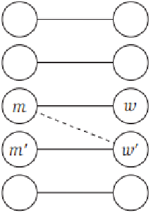

**Stable assignment**. Assignment with no instability.

- in a spontaneous way
- individual self-interest prevents side deals

How to formulated this story into a problem *mathematically*?

## Stable Matching Problem: Input

**Entities**. Set $M = \{m_1, m_2, ..., m_n\}$ and set $W = \{w_1, w_2, ..., w_n\}$, each has $n$ entities.

**Preference**. Each $m \in M$ *ranks* $W$ into $R_m$, and each $w \in W$ *ranks* $M$ into $R_w$.

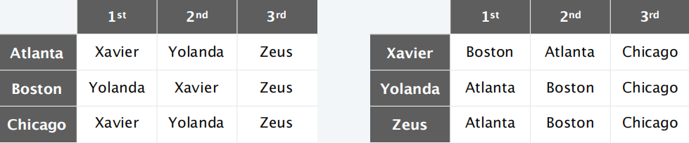

## Matching

Let $M \times W$ denote the set of all possible ordered pairs of the form $(m, w)$, where $m \in M$ and $w \in W$.

**Matching** is a subset of $M \times W$, where each $m \in M$ and $w \in W$ appears in at most one pair.

A matching $P$ is **perfect** if $|P| = |M| = |W| = n$.

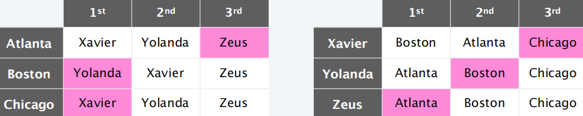

## Stable Matching Problem: Output

A **stable matching** is a perfect matching with no instability.

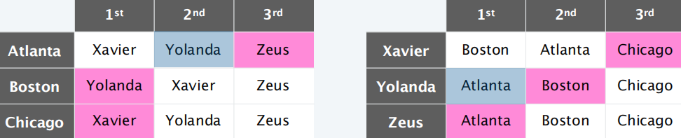

**Stable Matching Problem**. Given the preference lists, find a stable matching (if one exists).

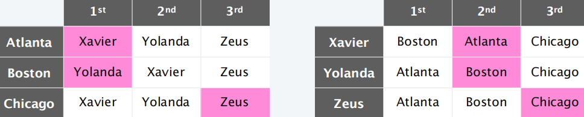

# Gale-Shapley Algorithm

## States

Clearly, each entity has two states in our current formulation: `free`, or `matched`.

- Is it enough? Let’s brainstorm a scenario where $m$ *proposes* to each $w \in W$.

If $w$ got proposed:

- might too rush to accept: better ones might come later.
- might too risky to reject: this could be the best ever comes.

We need a third state: `engaged`.

## State transitions

1. Initially, everyone is `free`.
2. Let’s say an arbitrary $m$ proposes to each $w \in W$:
   - in order of preference list $R_m$.
   - suppose $w$ got proposed, and if:
     - `free`: engage.
     - `engaged` to $m'$: check its preference list $R_w$:
       - $m'$ is higher: reject $m$, then $m$ will propose to next one.
       - $m$ is higher: engage $m$, which makes $m'$ `free`.
3. When everyone is `engaged`, claim it the final matching.

## Gale–Shapley algorithm

INPUT: $M, W, R_m, R_w$

1. $P = \varnothing$; mark $m \in M$ and $w \in W$ `free`;
2. WHILE some $m \in M$ is `free`
   1. $w$: highest on $R_m$ that $m$ has not yet proposed;
   2. IF $w$ is `free`
      1. Add $(m, w)$ to $P$;
   3. ELSE IF $w$ prefers $m$ to current partner $m'$
      1. Replace $(m', w)$ with $(m, w)$, set $m'$ `free`;
   4. ELSE (Nothing happens.);
3. RETURN $P$;

## Demo: G-S

# Proof of Correctness

## Termination

**Observation 1**. Each $m$ proposes in decreasing order of preference (getting worse and worse).

**Observation 2**. Once $w$ engaged, it’s never free again, but “trades up” (getting better and better).

**Claim**. G-S algorithm terminates after at most $n^2$ iterations.  
**Pf**. One of $M$ proposes to a new candidate in each iteration, and there are at most $n^2$ possible proposals.

## Perfect matching

**Claim**. G-S algorithm outputs a matching.  
**Pf**. [from observations]

- $m$ proposes only if free $\Rightarrow$ matched to at most 1
- $w$ keeps only the best $\Rightarrow$ matched to at most 1

**Claim**. In G-S matching, all $M$ get matched.  
**Pf**. [by contradiction]

- suppose $m \in M$ is still `free` upon termination.
- at least one $w \in W$ is unmatched.
- so $w$ was never proposed to.
- but $m$ proposed to everyone, contradiction.

**Claim**. G-S algorithm outputs a perfect matching.  
**Pf**. [by counting]

## Stability

**Claim**. [Gale–Shapley 1962] G-S algorithm outputs a stable matching $P^\ast$.  
**Pf**. Consider a pair $(m, w) \notin P^\ast$:

- $m$ never proposed to $w$
  - $m$ prefers its G-S partner $w'$ to $w$
- $m$ proposed to $w$
  - $w$ must rejected $m$ in the end
  - $w$ prefers its G-S partner $m'$ to $m$

In either case, current matching is more stable.

## Quiz: Uniqueness of G-S

Do all executions of Gale–Shapley lead to the same stable matching?

- No, because the algorithm is *nondeterministic*.
- No, because an instance can have several stable matchings.
- Yes, because each instance has a unique stable matching.
- Yes, even though an instance can have several stable matchings and the algorithm is nondeterministic.
- Nondeterministic? Yes.
- Multiple stable matchings? Yes.

We only show the matching will not change, but is it optimal? How to define optimal?

# (Exclusive) Optimality

## Completely Clashed Preferences

Consider the following preferences:

|  | 1<sup>st</sup> | <sup>2nd</sup> |  |  | 1<sup>st</sup> | <sup>2nd</sup> |
| --- | --- | --- | --- | --- | --- | --- |
| **$m$** | $w$ | $w'$ |  | **$w$** | $m'$ | $m$ |
| **$m'$** | $w'$ | $w$ |  | **$w'$** | $m$ | $m'$ |

- $\{(m, w), (m', w')\}$ is stable:
  - both men are as happy as possible, so neither would leave their matched partner.
- $\{(m', w), (m, w')\}$ is also stable:
  - for the complementary reason that neither women would leave their matched partner.

It’s possible for an instance to have more than one stable matching.

- Even possible to say they are equally good?

## Valid partner

**Def**. We say $m$ is a **valid partner** of $m$, if there *exists any* stable matching that contains the pair $(m, w)$.

[output not shown]

- Both X and Y are valid partners for A.
- Both X and Y are valid partners for B.
- Z is the only valid partner for C

Can you see the stable matchings?

## Best-valid assignment

**Def**. $w$ is the **best-valid partner** of $m$: if $(m, w)$ is *valid*, and no one else has a higher rank than $w$ is valid.

- $best(m)$: denote the best-valid partner of $m$.

**M-optimal assignment**. $S^\ast$ denote the set of pairs $\{(m, best(m)) : m \in M\}$.

- Is it a (perfect) matching?
- Is it stable?

**Claim**. Every executions of G-S yield $S^\ast$.

- Remember rules in G-S algorithm: only $M$ propose.

## M-optimality

**Claim**. Every executions of G-S yield $S^\ast$.  
**Pf**. suppose one of $M$ matched non-best-valid in $S$.

- $M$ propose in decreasing order of preference.
  - rejected by best-valid partner.
  - consider the *first moment* such rejection happened
    - Let $m$: *first* got rejected,
    - Let $w$: *first valid* that rejected $m$,
      - must be: $w = best(m)$.
    - Let $m'$: engaged to $w$ when $w$ rejected $m$,
      - $\star$: $w$ prefers $m'$ to $m$.

## M-optimality (cont.)

**Claim**. Every executions of G-S yield $S^\ast$.  
**Pf**. suppose one of $M$ matched non-best-valid in $S$.

- $M$ propose in decreasing order of preference.
  - consider the *first moment* such rejection happened
    - Let $m'$: engaged to $w$ when $w$ rejected $m$,
      - $\star$: $w$ prefers $m'$ to $m$.
- $(m, w)$ is valid, so exist stable match $S'$ contains it.
  - Let $w'$ be the partner of $m'$ in $S'$,
  - $m'$ not rejected by any valid partner *at the moment*.
    - especially, $m'$ not yet rejected by $w'$,
      - $m'$ not yet proposed to $w'$, but engaged,
      - $\star$: $m'$ prefers $w$ to $w'$.
- $(m', w)$ is an instability in $S'$, a contradiction.

## Exclusiveness of Optimality

M-optimality come at the expense of the other side.

- In $S^\ast$, each $w \in W$ got the *worst possible* partner.

**Def**. $m$ is the **worst-valid partner** of $w$: if $(m, w)$ is *valid*, and no one else has a lower rank than $m$ is valid.

- $worst(w)$: denote the worst-valid partner of $w$.

## W-pessimal

**Claim**. In $S^\ast$, each $w \in W$ is paired with $worst(w)$.  
**Pf**. suppose $(m, w) \in S^\ast$, but $m \ne worst(w)$.

## Is it fair?

When preferences clash completely:

- *proposing* side got best possible stable matching;
- the other side got worst possible stable matching.

*Someone* is destined to end up unhappy.

# Context

## Extensions

We made many assumptions in the problem formulation.

- Some agents declare others as unacceptable.
- Some companies have more than one position.
- Unequal number of positions and students.

**Def**. Matching $P$ is **unstable** if exists $(m, w) \notin P$:

- they are acceptable to each other;
- Either $w$ is unmatched, or $w$ prefers $m$ to assigned company;
- Either $m$ does not have all its places filled, or $m$ prefers $w$ to at least one of its assigned students.

**Theorem**. There exists a stable matching.  
**Pf**. Straightforward generalization of G-S algorithm.

## 2012 Nobel Prize in Economics

**Lloyd Shapley**. Stable matching theory and Gale–Shapley algorithm.

- original applications: college admissions and opposite-sex marriage.

**Alvin Roth**. Applied Gale–Shapley to matching med-school students with hospitals, students with schools, and organ donors with patients.

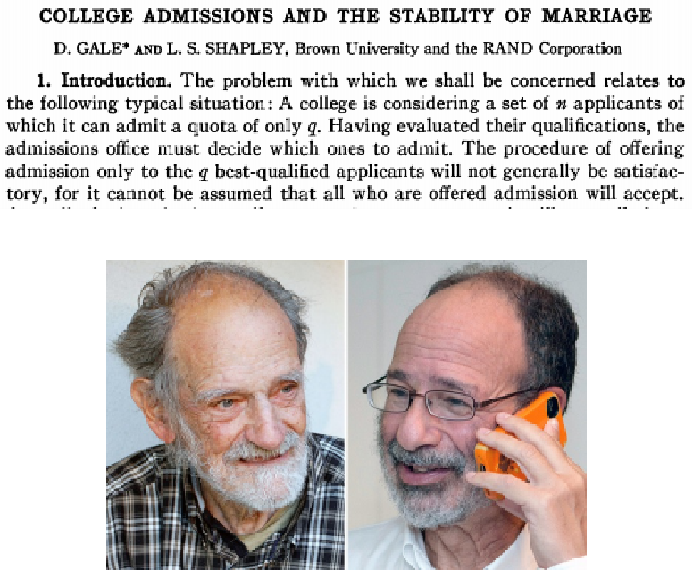

While talking algorithms, *it’s not just about computer science*.

# Five Representative Problems

## Recap: Problem solving steps

1. **formulate** the problem with *enough mathematical precision* that:
   - we can ask a concrete question,
   - and start thinking about algorithms to solve it;
2. **design** an algorithm for the problem;
3. **analyze** the algorithm to:
   - prove it is correct,
   - and give a bound on the running time (so as to establish the algorithm’s *efficiency*).

## Milestones

The course is structured by fundamental design techniques.

- *subtle changes* in the statement of a problem can have an *enormous effect* on its computational difficulty.
- **Interval Scheduling**: Greedy algorithms.
- **Weighted Interval Scheduling**: Dynamic programming.
- **Bipartite Matching**: Network flow.
- **Independent Set**: NP-complete.
- **Competitive Facility Location**: PSPACE-complete.